# Site Occupancy Lapin

08/08

## 1 Intallation des packages

```r
library(dplyr);library(ggplot2);library(sf);library(unmarked)
theme_set(theme_light(base_size = 16))
```

Fonctions -> A mettre dans les dossiers de fonctions apres

## 2 Importation des bases de donnees

```r
Total <- sf::st_read(paste0(wd$data, "derived/Total.shp"),
                     options = "ENCODING=UTF8")
```

```
## options:        ENCODING=UTF8
```

```r
Total <- Total%>%
  transform_Total()

VariablesSite <- sf::st_read(paste0(wd$data, "derived/VariablesSite.shp"),
                             options = "ENCODING=UTF8")
```

```
## options:        ENCODING=UTF8
```

```r
VariablesSite <- VariablesSite%>%
  transform_VarSites()
```

```r
Lapins <- Total %>%
  sf::st_join(VariablesSite) %>%
  filter(cd_nom == 61714,
         technique_observation == "Vu",
         date >= as.Date("2005-01-01")) %>%
  # select(-c(insee_dept, lib_dept, lib_dept, FID, surf, CD_SIG)) %>%
  select(-nom_valide, -nom_vernaculaire, -ordre, -technique_observation) %>%
  mutate(year = lubridate::year(date))
```

## 3 Creation de la base de donnee Detection - Non Detection

```r
detection_df <- Lapins %>%
  sf::st_drop_geometry() %>%
  dplyr::mutate(annee = lubridate::year(date)) %>%
  dplyr::select(Code_10km, annee) %>%
  dplyr::count(Code_10km, annee) %>%
  tidyr::complete(Code_10km,
                  annee = tidyr::full_seq(annee, 1),
                  fill = list(n = 0)) %>%
  tidyr::pivot_wider(names_from = annee,
                     values_from = n) %>%
  dplyr::arrange(Code_10km) %>%
  filter(!is.na(Code_10km))

detection_df[,-1] <- ifelse(detection_df[,-1]>0, 1, 0)

noms <- detection_df$Code_10km
detection_matrice <- as.matrix(detection_df[, -1])
rownames(detection_matrice) <- noms
```

```r
head(detection_matrice)
```

```
##          2005 2006 2007 2008 2009 2010 2011 2012 2013 2014 2015 2016 2017 2018 2019 2020 2021 2022 2023
## E012N679    0    0    0    0    0    0    0    1    0    1    1    1    1    1    1    0    1    1    1
## E012N683    0    0    0    0    0    0    0    0    1    0    1    1    1    1    1    1    0    1    1
## E012N684    0    0    0    0    0    0    0    0    0    0    0    0    1    0    1    1    1    1    1
## E012N685    0    0    0    0    0    0    0    0    1    1    1    0    0    0    1    1    1    1    1
## E013N679    0    1    0    0    0    0    0    1    1    0    1    0    0    1    1    1    1    1    1
## E013N680    0    0    0    0    0    0    0    0    0    0    0    0    1    1    1    0    1    1    1
##          2024 2025
## E012N679    1    0
## E012N683    1    0
## E012N684    1    1
## E012N685    1    1
## E013N679    1    1
## E013N680    1    1
```

```r
head(detection_df)
```

```
## # A tibble: 6 Ã 22
##   Code_10km `2005` `2006` `2007` `2008` `2009` `2010` `2011` `2012` `2013` `2014` `2015` `2016` `2017`
##   <fct>      <dbl>  <dbl>  <dbl>  <dbl>  <dbl>  <dbl>  <dbl>  <dbl>  <dbl>  <dbl>  <dbl>  <dbl>  <dbl>
## 1 E012N679       0      0      0      0      0      0      0      1      0      1      1      1      1
## 2 E012N683       0      0      0      0      0      0      0      0      1      0      1      1      1
## 3 E012N684       0      0      0      0      0      0      0      0      0      0      0      0      1
## 4 E012N685       0      0      0      0      0      0      0      0      1      1      1      0      0
## 5 E013N679       0      1      0      0      0      0      0      1      1      0      1      0      0
## 6 E013N680       0      0      0      0      0      0      0      0      0      0      0      0      1
## # â¹ 8 more variables: `2018` <dbl>, `2019` <dbl>, `2020` <dbl>, `2021` <dbl>, `2022` <dbl>,
## #   `2023` <dbl>, `2024` <dbl>, `2025` <dbl>
```

## 4 Covariables de site

```r
site_info <- VariablesSite %>%
  sf::st_drop_geometry() %>%
  dplyr::arrange(Code_10km)

noms <- site_info$Code_10km
rownames(site_info) <- noms

site_info <- site_info %>%
  dplyr::select(-Code_10km) %>%
  dplyr::rename(Dnst_Cultures = `Dnst_Cultures `)%>%
  dplyr::mutate(across(where(is.numeric),
                       scale))
```

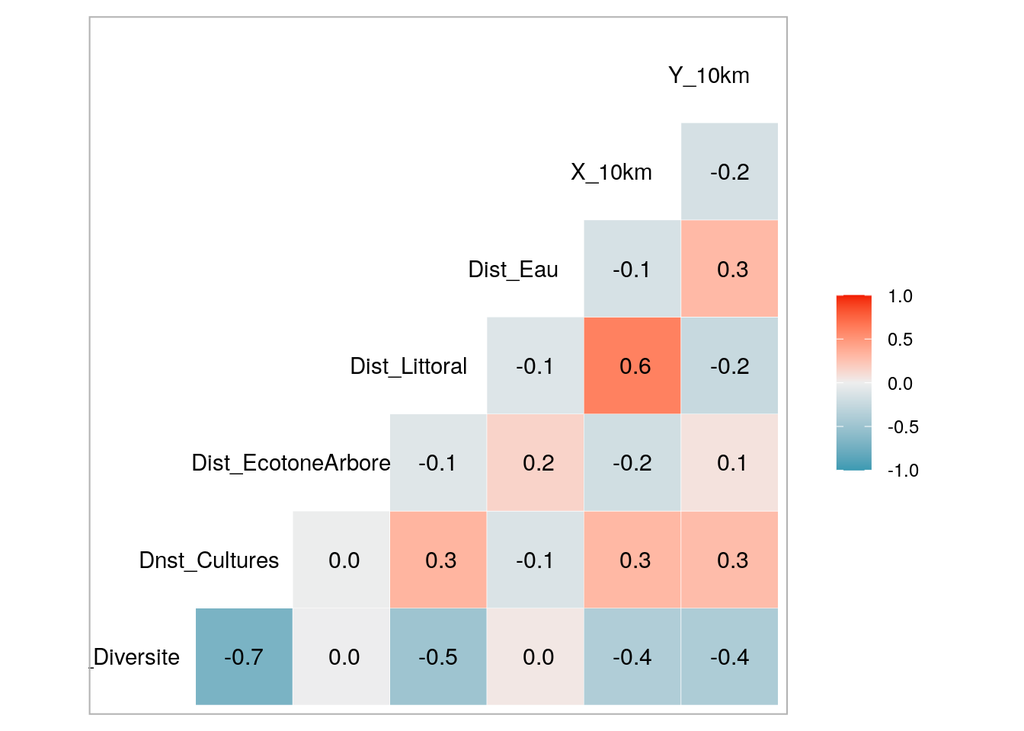

```r
site_info %>%
  dplyr::select(-air_km2) %>%
  dplyr::select_if(is.numeric) %>%
  GGally::ggcorr(label = TRUE, hjust = 0.75)
```

```r
names(site_info)
```

```
##  [1] "Ind_Diversite"      "Dnst_Cultures"      "Dist_EcotoneArbore" "Dist_Littoral"
##  [5] "Dist_Eau"           "Famille_paysage"    "Nom_paysage"        "air_km2"
##  [9] "X_10km"             "Y_10km"
```

[output not shown]

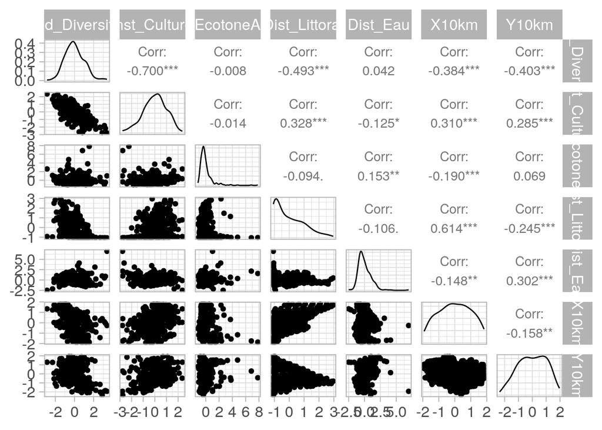

```r
df <- site_info%>%
  rename(X10km = X_10km,
         Y10km = Y_10km) %>%
  dplyr:: select(-air_km2) %>%
  dplyr::select_if(is.numeric)
df <- as.data.frame(lapply(df, as.numeric))
GGally::ggpairs(as.data.frame(lapply(df, as.numeric)))
```

On voit dans ces graphiques une forte correlation lineaire entre la densite de cultures et l’indice de diversite. On remarque aussi une correlation lineaire entre X et la distance au littoral. Graphiquement, on ne voit pas forcement de correlation particuliers de correlation dans les nuage de points, apart X et Y dans contre la distance au littoral, mais c’est pas forcement un probleme.

Comme ils le font dans l’etude avec les ours, on va se se retirer les covariables avec une correlation > 0.5 et regarder les diff combinaisons.

```r
head(site_info)
```

```
##          Ind_Diversite Dnst_Cultures Dist_EcotoneArbore Dist_Littoral   Dist_Eau
## E012N679     1.5378789    -2.2326745          7.8261108     -1.046618  1.5757199
## E012N683     0.2223354    -0.2095170          0.8321474     -1.024975 -0.4960337
## E012N684     1.1896119    -0.3698621          0.6409972     -1.011530 -0.4295444
## E012N685     0.7730780    -0.7771374          1.4702739     -1.046701  0.7376034
## E013N679     1.4211022    -0.6784294          0.9549556     -1.017641 -0.9758315
## E013N680    -0.1960513    -0.1942909          2.3770055     -1.038435 -0.4690547
##                     Famille_paysage     Nom_paysage   air_km2    X_10km     Y_10km
## E012N679 Paysage cultive avec talus Baie d'Audierne -3.067118 -1.855762 -0.4313955
## E012N683 Paysage cultive avec talus Plateau leonard -1.771457 -1.907639  0.5849887
## E012N684 Paysage cultive avec talus Plateau leonard -1.756103 -1.916688  0.8340685
## E012N685 Paysage cultive avec talus Plateau leonard -2.963402 -1.916467  1.0530417
## E013N679 Paysage cultive avec talus Baie d'Audierne -1.497667 -1.744799 -0.4476277
## E013N680 Paysage cultive avec talus Baie d'Audierne -2.577417 -1.752710 -0.3377688
```

```r
summary(site_info)
```

```
##        Ind_Diversite.V1             Dnst_Cultures.V1         Dist_EcotoneArbore.V1
##  Min.   :-2.865708445210000   Min.   :-2.78214762389e+00   Min.   :-1.177548563760
##  1st Qu.:-0.679780380756000   1st Qu.:-6.39147940409e-01   1st Qu.:-0.538861888256
##  Median :-0.103681984768000   Median : 6.52166412662e-02   Median :-0.234385970959
##  Mean   : 0.000000000000001   Mean   : 2.00000000000e-16   Mean   : 0.000000000000
##  3rd Qu.: 0.590728352478000   3rd Qu.: 6.59758341030e-01   3rd Qu.: 0.149328232852
##  Max.   : 3.387273586330000   Max.   : 2.36743641082e+00   Max.   : 7.826110849440
##
##      Dist_Littoral.V1             Dist_Eau.V1                                    Famille_paysage
##  Min.   :-1.070027865720   Min.   :-2.486983274260   Paysage cultive a ragosses          :90
##  1st Qu.:-0.915859784196   1st Qu.:-0.653550370660   Paysage boise et de bosquets        :57
##  Median :-0.266683896501   Median :-0.230018369783   Paysage cultive avec talus          :52
##  Mean   : 0.000000000000   Mean   : 0.000000000000   Paysage de bocage a maille elargie  :41
##  3rd Qu.: 0.699371185739   3rd Qu.: 0.584178367602   Paysage de bocage dense sur collines:34
##  Max.   : 2.957617628370   Max.   : 6.943084217390   Paysage de littoral urbanise        :27
##                                                      (Other)                             :16
##                         Nom_paysage         air_km2.V1                  X_10km.V1
##  Reliefs des Landes de Lanvaux: 36   Min.   :-3.199398376490   Min.   :-1.91668816575e+00
##  Plateau de Penthievre        : 20   1st Qu.: 0.131669308234   1st Qu.:-7.91009617370e-01
##  Bassin de Pontivy-Loudeac    : 18   Median : 0.522356248052   Median : 1.43352452421e-03
##  Armor morbihannais           : 17   Mean   : 0.000000000000   Mean   : 1.00000000000e-16
##  Bassin de Rennes             : 17   3rd Qu.: 0.522356248055   3rd Qu.: 8.11993642375e-01
##  Cornouaille interieure       : 16   Max.   : 0.522356248061   Max.   : 1.82993231695e+00
##  (Other)                      :193
##           Y_10km.V1
##  Min.   :-2.36529227433e+00
##  1st Qu.:-7.80490736624e-01
##  Median : 1.54633653399e-02
##  Mean   : 1.07000000000e-14
##  3rd Qu.: 8.34068493645e-01
##  Max.   : 1.96182815611e+00
##
```

## 5 Implementation du Model

```r
head(detection_df)
```

```
## # A tibble: 6 Ã 22
##   Code_10km `2005` `2006` `2007` `2008` `2009` `2010` `2011` `2012` `2013` `2014` `2015` `2016` `2017`
##   <fct>      <dbl>  <dbl>  <dbl>  <dbl>  <dbl>  <dbl>  <dbl>  <dbl>  <dbl>  <dbl>  <dbl>  <dbl>  <dbl>
## 1 E012N679       0      0      0      0      0      0      0      1      0      1      1      1      1
## 2 E012N683       0      0      0      0      0      0      0      0      1      0      1      1      1
## 3 E012N684       0      0      0      0      0      0      0      0      0      0      0      0      1
## 4 E012N685       0      0      0      0      0      0      0      0      1      1      1      0      0
## 5 E013N679       0      1      0      0      0      0      0      1      1      0      1      0      0
## 6 E013N680       0      0      0      0      0      0      0      0      0      0      0      0      1
## # â¹ 8 more variables: `2018` <dbl>, `2019` <dbl>, `2020` <dbl>, `2021` <dbl>, `2022` <dbl>,
## #   `2023` <dbl>, `2024` <dbl>, `2025` <dbl>
```

Mise sous format pour la modelisation

```r
dim(detection_matrice)
```

```
## [1] 317  21
```

```r
dim(periodes_df)
```

```
## [1] 317  21
```

```r
dim(site_info)
```

```
## [1] 317  10
```

```r
umf <- unmarked::unmarkedFrameOccu(y = detection_matrice,
                                   obsCovs = list(periode = periodes_df),
                                   siteCovs = site_info
                                   )
```

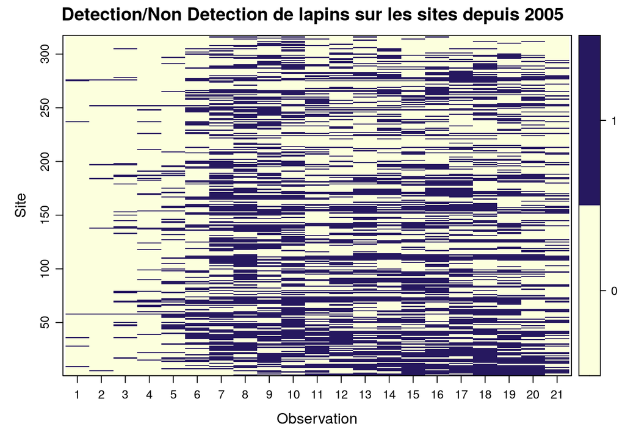

```r
unmarked::plot(umf, main="Detection/Non Detection de lapins sur les sites depuis 2005")
```

```r
head(umf); summary(umf)
```

```
## Data frame representation of unmarkedFrame object.
##          y.1 y.2 y.3 y.4 y.5 y.6 y.7 y.8 y.9 y.10 y.11 y.12 y.13 y.14 y.15 y.16 y.17 y.18 y.19 y.20
## E012N679   0   0   0   0   0   0   0   1   0    1    1    1    1    1    1    0    1    1    1    1
## E012N683   0   0   0   0   0   0   0   0   1    0    1    1    1    1    1    1    0    1    1    1
## E012N684   0   0   0   0   0   0   0   0   0    0    0    0    1    0    1    1    1    1    1    1
## E012N685   0   0   0   0   0   0   0   0   1    1    1    0    0    0    1    1    1    1    1    1
## E013N679   0   1   0   0   0   0   0   1   1    0    1    0    0    1    1    1    1    1    1    1
## E013N680   0   0   0   0   0   0   0   0   0    0    0    0    1    1    1    0    1    1    1    1
## E013N682   0   0   0   0   1   1   1   0   0    0    0    0    1    1    1    1    1    1    1    1
## E013N683   0   0   0   0   0   0   0   1   0    1    1    1    1    0    1    1    1    1    1    1
## E013N684   1   0   0   0   0   0   1   1   1    1    1    1    1    1    1    1    1    1    1    1
## E013N685   0   0   0   0   0   1   0   1   0    1    1    1    1    1    1    1    1    1    1    1
##          y.21 Ind_Diversite Dnst_Cultures Dist_EcotoneArbore Dist_Littoral   Dist_Eau
## E012N679    0    1.53787893    -2.2326745          7.8261108    -1.0466179  1.5757199
## E012N683    0    0.22233544    -0.2095170          0.8321474    -1.0249755 -0.4960337
## E012N684    1    1.18961192    -0.3698621          0.6409972    -1.0115303 -0.4295444
## E012N685    1    0.77307802    -0.7771374          1.4702739    -1.0467005  0.7376034
## E013N679    1    1.42110222    -0.6784294          0.9549556    -1.0176413 -0.9758315
## E013N680    1   -0.19605131    -0.1942909          2.3770055    -1.0384353 -0.4690547
## E013N682    0    0.83153243    -2.7666805          6.8511847    -1.0622859  2.1403731
## E013N683    1   -0.73150102     0.5530468         -0.2169224    -0.9197892 -0.4436418
## E013N684    0    0.01681583     0.3813047         -0.4400208    -0.8148766 -0.7679492
## E013N685    0   -0.16338814     0.2552194          1.5995116    -0.9619190 -0.1148823
##                     Famille_paysage           Nom_paysage    air_km2    X_10km     Y_10km periode.1
## E012N679 Paysage cultive avec talus       Baie d'Audierne -3.0671180 -1.855762 -0.4313955  periode1
## E012N683 Paysage cultive avec talus       Plateau leonard -1.7714567 -1.907639  0.5849887  periode1
## E012N684 Paysage cultive avec talus       Plateau leonard -1.7561033 -1.916688  0.8340685  periode1
## E012N685 Paysage cultive avec talus       Plateau leonard -2.9634019 -1.916467  1.0530417  periode1
## E013N679 Paysage cultive avec talus       Baie d'Audierne -1.4976667 -1.744799 -0.4476277  periode1
## E013N680 Paysage cultive avec talus       Baie d'Audierne -2.5774171 -1.752710 -0.3377688  periode1
## E013N682 Paysage cultive avec talus Crozon-Aulne maritime -2.7141188 -1.747912  0.3084349  periode1
## E013N683 Paysage cultive avec talus Crozon-Aulne maritime -0.3584249 -1.801403  0.6210106  periode1
## E013N684 Paysage cultive avec talus       Plateau leonard  0.5223562 -1.816081  0.8686968  periode1
## E013N685 Paysage cultive avec talus       Plateau leonard -0.4314269 -1.825159  1.1146680  periode1
##          periode.2 periode.3 periode.4 periode.5 periode.6 periode.7 periode.8 periode.9 periode.10
## E012N679  periode1  periode1  periode1  periode1  periode1  periode1  periode1  periode1   periode1
## E012N683  periode1  periode1  periode1  periode1  periode1  periode1  periode1  periode1   periode1
## E012N684  periode1  periode1  periode1  periode1  periode1  periode1  periode1  periode1   periode1
## E012N685  periode1  periode1  periode1  periode1  periode1  periode1  periode1  periode1   periode1
## E013N679  periode1  periode1  periode1  periode1  periode1  periode1  periode1  periode1   periode1
```

[output cut: 12 more lines]

```
## E013N682   periode2   periode2   periode2   periode2   periode2   periode2   periode2   periode2
## E013N683   periode2   periode2   periode2   periode2   periode2   periode2   periode2   periode2
## E013N684   periode2   periode2   periode2   periode2   periode2   periode2   periode2   periode2
## E013N685   periode2   periode2   periode2   periode2   periode2   periode2   periode2   periode2
##          periode.19 periode.20 periode.21
## E012N679   periode2   periode2   periode2
## E012N683   periode2   periode2   periode2
## E012N684   periode2   periode2   periode2
## E012N685   periode2   periode2   periode2
## E013N679   periode2   periode2   periode2
## E013N680   periode2   periode2   periode2
## E013N682   periode2   periode2   periode2
## E013N683   periode2   periode2   periode2
## E013N684   periode2   periode2   periode2
## E013N685   periode2   periode2   periode2
```

```
## unmarkedFrame Object
##
## 317 sites
## Maximum number of observations per site: 21
## Mean number of observations per site: 21
## Sites with at least one detection: 307
##
## Tabulation of y observations:
##    0    1
## 4272 2385
##
## Site-level covariates:
##        Ind_Diversite.V1             Dnst_Cultures.V1         Dist_EcotoneArbore.V1
##  Min.   :-2.865708445210000   Min.   :-2.78214762389e+00   Min.   :-1.177548563760
##  1st Qu.:-0.679780380756000   1st Qu.:-6.39147940409e-01   1st Qu.:-0.538861888256
##  Median :-0.103681984768000   Median : 6.52166412662e-02   Median :-0.234385970959
##  Mean   : 0.000000000000001   Mean   : 2.00000000000e-16   Mean   : 0.000000000000
##  3rd Qu.: 0.590728352478000   3rd Qu.: 6.59758341030e-01   3rd Qu.: 0.149328232852
##  Max.   : 3.387273586330000   Max.   : 2.36743641082e+00   Max.   : 7.826110849440
##
##      Dist_Littoral.V1             Dist_Eau.V1                                    Famille_paysage
##  Min.   :-1.070027865720   Min.   :-2.486983274260   Paysage cultive a ragosses          :90
##  1st Qu.:-0.915859784196   1st Qu.:-0.653550370660   Paysage boise et de bosquets        :57
##  Median :-0.266683896501   Median :-0.230018369783   Paysage cultive avec talus          :52
##  Mean   : 0.000000000000   Mean   : 0.000000000000   Paysage de bocage a maille elargie  :41
##  3rd Qu.: 0.699371185739   3rd Qu.: 0.584178367602   Paysage de bocage dense sur collines:34
##  Max.   : 2.957617628370   Max.   : 6.943084217390   Paysage de littoral urbanise        :27
##                                                      (Other)                             :16
##                         Nom_paysage         air_km2.V1                  X_10km.V1
##  Reliefs des Landes de Lanvaux: 36   Min.   :-3.199398376490   Min.   :-1.91668816575e+00
##  Plateau de Penthievre        : 20   1st Qu.: 0.131669308234   1st Qu.:-7.91009617370e-01
##  Bassin de Pontivy-Loudeac    : 18   Median : 0.522356248052   Median : 1.43352452421e-03
##  Armor morbihannais           : 17   Mean   : 0.000000000000   Mean   : 1.00000000000e-16
##  Bassin de Rennes             : 17   3rd Qu.: 0.522356248055   3rd Qu.: 8.11993642375e-01
##  Cornouaille interieure       : 16   Max.   : 0.522356248061   Max.   : 1.82993231695e+00
##  (Other)                      :193
##           Y_10km.V1
##  Min.   :-2.36529227433e+00
##  1st Qu.:-7.80490736624e-01
##  Median : 1.54633653399e-02
##  Mean   : 1.07000000000e-14
##  3rd Qu.: 8.34068493645e-01
##  Max.   : 1.96182815611e+00
##
##
## Observation-level covariates:
##      periode
##  periode1:3170
##  periode2:3487
```

On retirera ensuite les annees [2005 - 2009]. J’ai longtemps hesite entre garder 2009, ou 2025. Les 2 ont peu de donnees par rapport aux reste (2025 ca je n’ai pas l’annee entiere, et 2009 car c’est tôt). Les deux participerait a augementer la probabilite de detection.

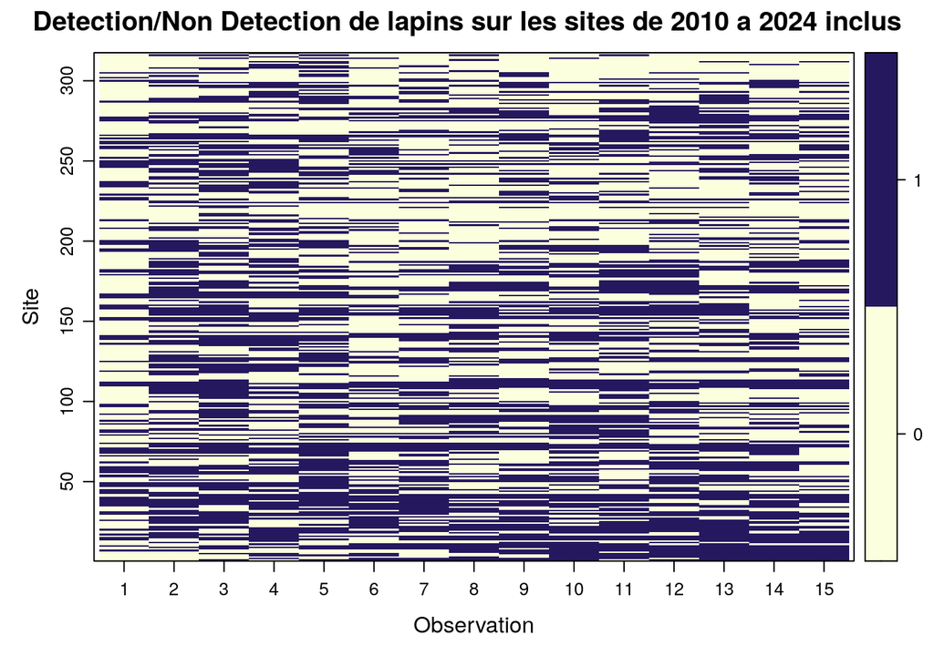

```r
Lapins <- Total %>%
  sf::st_join(VariablesSite) %>%
  filter(cd_nom == 61714,
         technique_observation == "Vu",
         date >= as.Date("2010-01-01"),
         date < as.Date("2025-01-01")) %>%
  # select(-c(insee_dept, lib_dept, lib_dept, FID, surf, CD_SIG)) %>%
  select(-nom_valide, -nom_vernaculaire, -ordre, -technique_observation) %>%
  mutate(year = lubridate::year(date))

detection_df <- Lapins %>%
  sf::st_drop_geometry() %>%
  dplyr::mutate(annee = lubridate::year(date)) %>%
  dplyr::select(Code_10km, annee) %>%
  dplyr::count(Code_10km, annee) %>%
  tidyr::complete(Code_10km,
                  annee = tidyr::full_seq(annee, 1),
                  fill = list(n = 0)) %>%
  tidyr::pivot_wider(names_from = annee,
                     values_from = n) %>%
  dplyr::arrange(Code_10km) %>%
  filter(!is.na(Code_10km))

detection_df[,-1] <- ifelse(detection_df[,-1]>0, 1, 0)

noms <- detection_df$Code_10km
detection_matrice <- as.matrix(detection_df[, -1])
rownames(detection_matrice) <- noms

umf <- unmarked::unmarkedFrameOccu(y = detection_matrice,
                                   siteCovs = site_info
                                   )

unmarked::plot(umf, main="Detection/Non Detection de lapins sur les sites de 2010 a 2024 inclus")
```

## 6 Resultats

### 6.1 Modeles d’occupation a une seule saison

Un model de base sans variables

```r
model_null <- unmarked::occu(~1 ~1, data = umf)
unmarked::summary(model_null)
```

```
##
## Call:
## unmarked::occu(formula = ~1 ~ 1, data = umf)
##
## Occupancy (logit-scale):
##  Estimate    SE    z  P(>|z|)
##      3.43 0.322 10.6 1.92e-26
##
## Detection (logit-scale):
##  Estimate     SE     z  P(>|z|)
##    -0.108 0.0295 -3.67 0.000242
##
## AIC: 6463.181
## Number of sites: 317
```

```r
backTransform(model_null, type="state")
```

```
## Backtransformed linear combination(s) of Occupancy estimate(s)
##
##  Estimate      SE LinComb (Intercept)
##     0.969 0.00982    3.43           1
##
## Transformation: logistic
```

```r
backTransform(model_null, type="det")
```

```
## Backtransformed linear combination(s) of Detection estimate(s)
##
##  Estimate      SE LinComb (Intercept)
##     0.473 0.00736  -0.108           1
##
## Transformation: logistic
```

```r
confint(backTransform(model_null, type="state"))
```

```
##      0.025     0.975
##  0.9424205 0.9830019
```

```r
confint(backTransform(model_null, type="det"))
```

```
##      0.025    0.975
##  0.4585328 0.487377
```

```r
coef(model_null)
```

```
##   psi(Int)     p(Int)
##  3.4263979 -0.1083766
```

On a egalement les intervalles de confiances qui sont assez serres autour de ces valeurs a 95%.

```r
model_eau <- unmarked::occu(~1 ~ Dist_Eau, data = umf)
unmarked::summary(model_eau)
```

```
##
## Call:
## unmarked::occu(formula = ~1 ~ Dist_Eau, data = umf)
##
## Occupancy (logit-scale):
##             Estimate    SE      z P(>|z|)
## (Intercept)    3.435 0.325 10.585 3.5e-26
## Dist_Eau      -0.133 0.285 -0.468 6.4e-01
##
## Detection (logit-scale):
##  Estimate     SE     z  P(>|z|)
##    -0.108 0.0295 -3.67 0.000242
##
## AIC: 6464.98
## Number of sites: 317
```

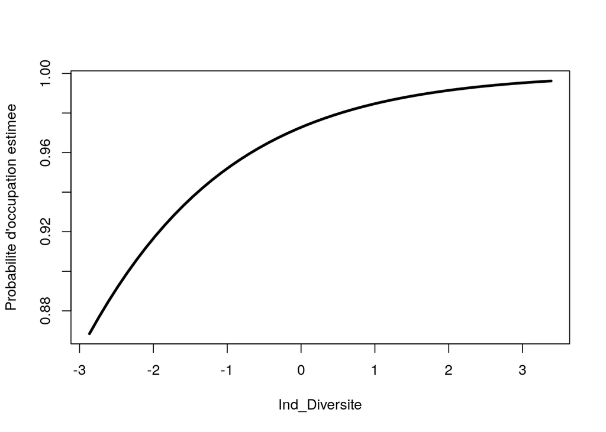

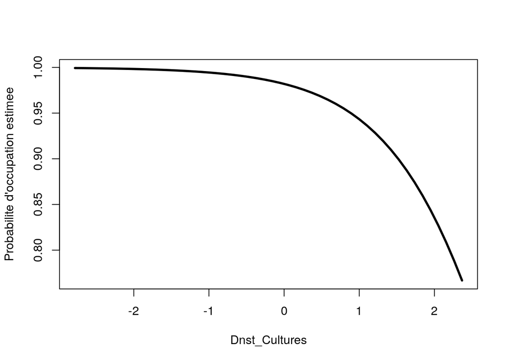

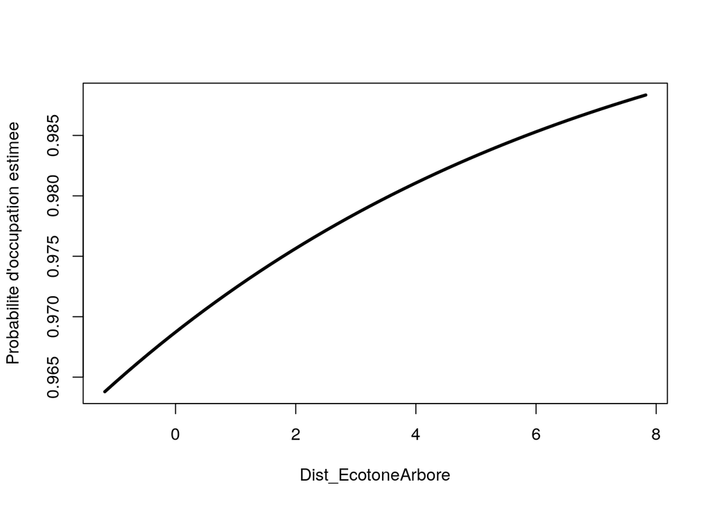

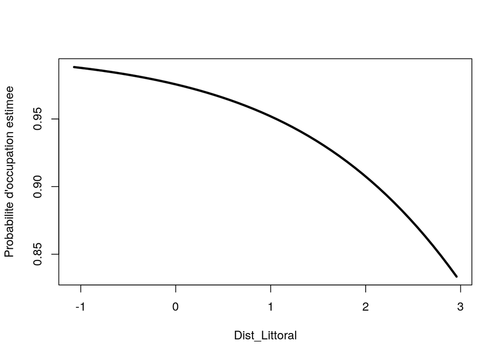

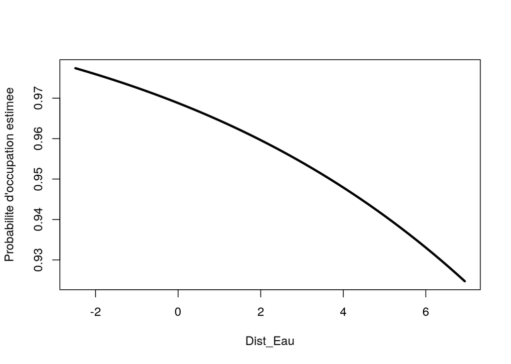

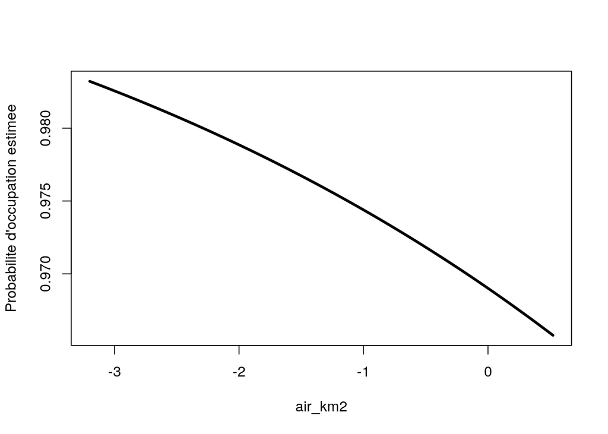

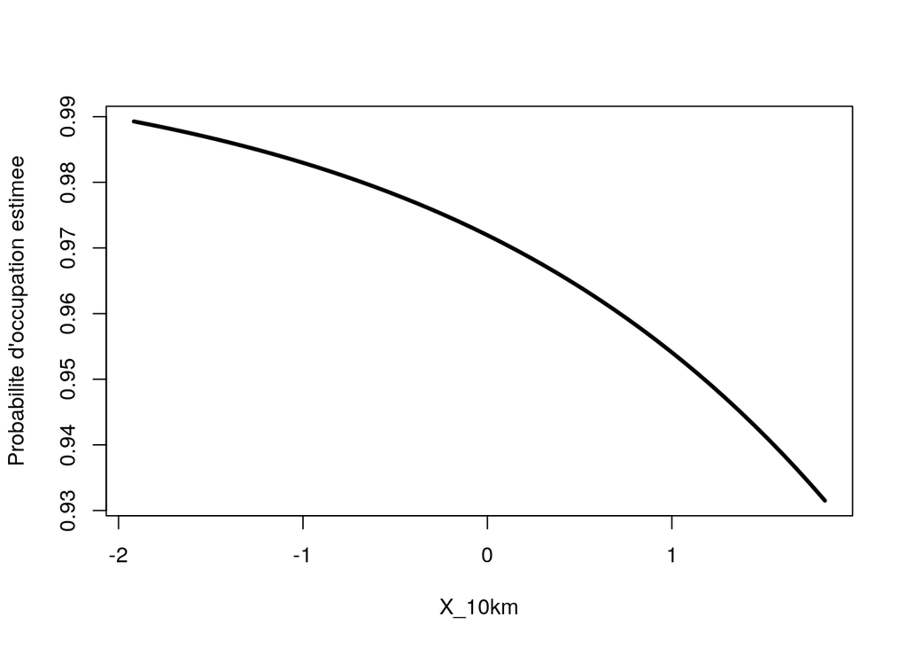

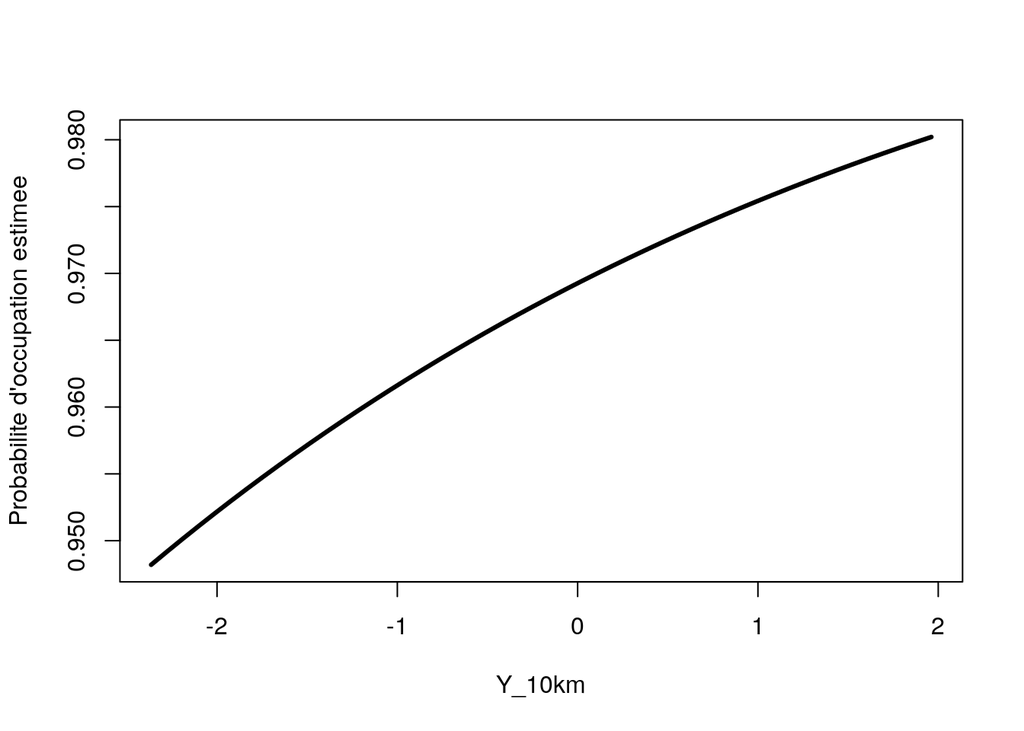

```r
noms_site_info <- c("Ind_Diversite", "Dnst_Cultures", "Dist_EcotoneArbore", "Dist_Littoral",
                    "Dist_Eau", "air_km2", "X_10km", "Y_10km")

for (i in noms_site_info) {
  formule <- as.formula(paste("~1 ~", i))

  model <- unmarked::occu(formule, data = umf)

  grid <- seq(min(site_info[[i]], na.rm=TRUE),
              max(site_info[[i]], na.rm=TRUE),
              length=50)

  occ_pred <- plogis(coef(model)[1] + coef(model)[2] * grid)

  # Plot
  plot(grid,
       occ_pred,
       type = "l",
       lwd = 3,
       xlab = i,
       ylab = "Probabilite d'occupation estimee")
}
```

On voit la relation entre la couverture et la probabilite d’occupancy. Legerement decroissante et tres legerement concave.

Comparaison de plusieurs models

```r
model_null <- unmarked::occu(~1 ~ 1, data = umf)
model_eau <- unmarked::occu(~1 ~ Dist_Eau, data = umf)
model_litt <- unmarked::occu(~1 ~ Dist_Littoral, data = umf)
model_litt_eau <- unmarked::occu(~1 ~ Dist_Littoral + Dist_Eau,
                                 data = umf)

fmList <- unmarked::fitList('{psi, p}' = model_null,
                  '{psi(dist_eau), p}' = model_eau,
                  '{psi(dist_littoral), p}' = model_litt,
                  '{psi(dist_littoral + dist_eau), p}' = model_litt_eau)

unmarked::modSel(fmList)
```

```
##                                    nPars     AIC delta AICwt cumltvWt
## {psi(dist_littoral), p}                3 6459.21  0.00 0.576     0.58
## {psi(dist_littoral + dist_eau), p}     4 6460.43  1.22 0.313     0.89
## {psi, p}                               2 6463.18  3.97 0.079     0.97
## {psi(dist_eau), p}                     3 6464.98  5.77 0.032     1.00
```

### 6.2 Modeles d’occupation a plusieurs saisons

Sites are closed within seasons but can change across seasons due to colonisation/extinction events (Markov Chain model)

Peut etre colonise ou pas colonise (faire matrice dans mon livrable stat). graphique?

Ici pas de fausses positives.

on a psi : prop occupation p: prop detection gamma : prob de colonisation epsilon : probabilite d’extinction

On suppose comme dans MC que hop cest hyper rapide, instantane meme qu’on soit extinct ou colonise entre les sites. Au sein du même site, on n’as pas ces fluctuations.

(changer le highlight tango, theme dans le — en haut)

On va mapper aussi. -> remettre le sf

```r
annees <- as.numeric(colnames(detection_matrice))

quali_periodes_vector <-   dplyr::case_when(annees < 2015 ~ "periode1",
                                            annees < 2020 ~ "periode2",
                                            annees < 2025 ~ "periode3")

quali_periodes_matrice <- matrix(rep(quali_periodes_vector,
                                     each = nrow(detection_df)),
                           nrow = nrow(detection_df),
                           byrow = FALSE)

colnames(quali_periodes_matrice) <- colnames(detection_matrice)
rownames(quali_periodes_matrice) <- rownames(detection_matrice)
quali_periodes_df <- as.data.frame(quali_periodes_matrice)
```

```r
head(quali_periodes_matrice)
```

```
##          2010       2011       2012       2013       2014       2015       2016       2017
## E012N679 "periode1" "periode1" "periode1" "periode1" "periode1" "periode2" "periode2" "periode2"
## E012N683 "periode1" "periode1" "periode1" "periode1" "periode1" "periode2" "periode2" "periode2"
## E012N684 "periode1" "periode1" "periode1" "periode1" "periode1" "periode2" "periode2" "periode2"
## E012N685 "periode1" "periode1" "periode1" "periode1" "periode1" "periode2" "periode2" "periode2"
## E013N679 "periode1" "periode1" "periode1" "periode1" "periode1" "periode2" "periode2" "periode2"
## E013N680 "periode1" "periode1" "periode1" "periode1" "periode1" "periode2" "periode2" "periode2"
##          2018       2019       2020       2021       2022       2023       2024
## E012N679 "periode2" "periode2" "periode3" "periode3" "periode3" "periode3" "periode3"
## E012N683 "periode2" "periode2" "periode3" "periode3" "periode3" "periode3" "periode3"
## E012N684 "periode2" "periode2" "periode3" "periode3" "periode3" "periode3" "periode3"
## E012N685 "periode2" "periode2" "periode3" "periode3" "periode3" "periode3" "periode3"
## E013N679 "periode2" "periode2" "periode3" "periode3" "periode3" "periode3" "periode3"
## E013N680 "periode2" "periode2" "periode3" "periode3" "periode3" "periode3" "periode3"
```

```r
dim(quali_periodes_matrice)
```

```
## [1] 317  15
```

```r
quanti_periodes_vector <-   dplyr::case_when(annees < 2015 ~ 1,
                                             annees < 2020 ~ 2,
                                             annees < 2025 ~ 3)
quanti_periodes_matrice <- matrix(rep(quanti_periodes_vector,
                               each = nrow(detection_df)),
                           nrow = nrow(detection_df),
                           byrow = FALSE)

colnames(quanti_periodes_matrice) <- colnames(detection_matrice)
rownames(quanti_periodes_matrice) <- rownames(detection_matrice)
quanti_periodes_df <- as.data.frame(quanti_periodes_matrice)
```

```r
head(quanti_periodes_matrice)
```

```
##          2010 2011 2012 2013 2014 2015 2016 2017 2018 2019 2020 2021 2022 2023 2024
## E012N679    1    1    1    1    1    2    2    2    2    2    3    3    3    3    3
## E012N683    1    1    1    1    1    2    2    2    2    2    3    3    3    3    3
## E012N684    1    1    1    1    1    2    2    2    2    2    3    3    3    3    3
## E012N685    1    1    1    1    1    2    2    2    2    2    3    3    3    3    3
## E013N679    1    1    1    1    1    2    2    2    2    2    3    3    3    3    3
## E013N680    1    1    1    1    1    2    2    2    2    2    3    3    3    3    3
```

```r
dim(quanti_periodes_matrice)
```

```
## [1] 317  15
```

Variable numerique pas (continue) avant c’est qualitative.

```r
site_covs_periodes <- list(
  quanti_periodes = quanti_periodes_matrice,
  quali_periodes = quali_periodes_matrice
)
```

```r
detections_per_year = colSums(detection_matrice)

print(detections_per_year)
```

```
## 2010 2011 2012 2013 2014 2015 2016 2017 2018 2019 2020 2021 2022 2023 2024
##   95  165  179  158  166  123  140  134  147  143  158  153  152  143  122
```

```r
umf <- unmarked::unmarkedMultFrame(y = detection_matrice,
                                   siteCovs = site_info,
                                   yearlySiteCovs = site_covs_periodes,
                                   numPrimary = 15)
summary(umf)
```

```
## unmarkedFrame Object
##
## 317 sites
## Maximum number of observations per site: 15
## Mean number of observations per site: 15
## Number of primary survey periods: 15
## Number of secondary survey periods: 1
## Sites with at least one detection: 307
##
## Tabulation of y observations:
##    0    1
## 2577 2178
##
## Site-level covariates:
##        Ind_Diversite.V1             Dnst_Cultures.V1         Dist_EcotoneArbore.V1
##  Min.   :-2.865708445210000   Min.   :-2.78214762389e+00   Min.   :-1.177548563760
##  1st Qu.:-0.679780380756000   1st Qu.:-6.39147940409e-01   1st Qu.:-0.538861888256
##  Median :-0.103681984768000   Median : 6.52166412662e-02   Median :-0.234385970959
##  Mean   : 0.000000000000001   Mean   : 2.00000000000e-16   Mean   : 0.000000000000
##  3rd Qu.: 0.590728352478000   3rd Qu.: 6.59758341030e-01   3rd Qu.: 0.149328232852
##  Max.   : 3.387273586330000   Max.   : 2.36743641082e+00   Max.   : 7.826110849440
##
##      Dist_Littoral.V1             Dist_Eau.V1                                    Famille_paysage
##  Min.   :-1.070027865720   Min.   :-2.486983274260   Paysage cultive a ragosses          :90
##  1st Qu.:-0.915859784196   1st Qu.:-0.653550370660   Paysage boise et de bosquets        :57
##  Median :-0.266683896501   Median :-0.230018369783   Paysage cultive avec talus          :52
##  Mean   : 0.000000000000   Mean   : 0.000000000000   Paysage de bocage a maille elargie  :41
##  3rd Qu.: 0.699371185739   3rd Qu.: 0.584178367602   Paysage de bocage dense sur collines:34
##  Max.   : 2.957617628370   Max.   : 6.943084217390   Paysage de littoral urbanise        :27
##                                                      (Other)                             :16
##                         Nom_paysage         air_km2.V1                  X_10km.V1
##  Reliefs des Landes de Lanvaux: 36   Min.   :-3.199398376490   Min.   :-1.91668816575e+00
##  Plateau de Penthievre        : 20   1st Qu.: 0.131669308234   1st Qu.:-7.91009617370e-01
##  Bassin de Pontivy-Loudeac    : 18   Median : 0.522356248052   Median : 1.43352452421e-03
##  Armor morbihannais           : 17   Mean   : 0.000000000000   Mean   : 1.00000000000e-16
##  Bassin de Rennes             : 17   3rd Qu.: 0.522356248055   3rd Qu.: 8.11993642375e-01
##  Cornouaille interieure       : 16   Max.   : 0.522356248061   Max.   : 1.82993231695e+00
##  (Other)                      :193
##           Y_10km.V1
##  Min.   :-2.36529227433e+00
##  1st Qu.:-7.80490736624e-01
##  Median : 1.54633653399e-02
##  Mean   : 1.07000000000e-14
##  3rd Qu.: 8.34068493645e-01
##  Max.   : 1.96182815611e+00
##
##
## Yearly-site-level covariates:
##  quanti_periodes  quali_periodes
##  Min.   :1       periode1:1585
##  1st Qu.:1       periode2:1585
##  Median :2       periode3:1585
##  Mean   :2
##  3rd Qu.:3
##  Max.   :3
```

```r
fm0 <- colext(
  psiformula = ~ 1,     # initial occupancy
  gammaformula =  ~ 1,  # colonization
  epsilonformula = ~ 1, # extinction
  pformula = ~ 1,  # detection
  data = umf, # data
  control = list(trace = 1)
  )
summary(fm0)
```

```
##
## Call:
## colext(psiformula = ~1, gammaformula = ~1, epsilonformula = ~1,
##     pformula = ~1, data = umf, control = list(trace = 1))
##
## Initial (logit-scale):
##  Estimate    SE     z P(>|z|)
##    -0.251 0.176 -1.43   0.154
##
## Colonization (logit-scale):
##  Estimate     SE     z  P(>|z|)
##     -0.97 0.0782 -12.4 2.55e-35
##
## Extinction (logit-scale):
##  Estimate    SE     z  P(>|z|)
##     -1.56 0.136 -11.5 2.19e-30
##
## Detection (logit-scale):
##  Estimate    SE    z  P(>|z|)
##      1.23 0.133 9.22 3.05e-20
##
## AIC: 6014.864
## Number of sites: 317
```

colonisation

```r
unmarked::backTransform(fm0, type="col")
```

```
## Backtransformed linear combination(s) of Colonization estimate(s)
##
##  Estimate     SE LinComb (Intercept)
##     0.275 0.0156   -0.97           1
##
## Transformation: logistic
```

extinction

```r
unmarked::backTransform(fm0, type="ext")
```

```
## Backtransformed linear combination(s) of Extinction estimate(s)
##
##  Estimate     SE LinComb (Intercept)
##     0.174 0.0195   -1.56           1
##
## Transformation: logistic
```

initial occupancy

```r
unmarked::backTransform(fm0, type="psi")
```

```
## Backtransformed linear combination(s) of Initial estimate(s)
##
##  Estimate     SE LinComb (Intercept)
##     0.438 0.0433  -0.251           1
##
## Transformation: logistic
```

```r
unmarked::backTransform(fm0, type="det")
```

```
## Backtransformed linear combination(s) of Detection estimate(s)
##
##  Estimate     SE LinComb (Intercept)
##     0.774 0.0234    1.23           1
##
## Transformation: logistic
```

Model

On essaye plusieurs sans la variance, puis selon l’AIC, on calcule l’AIC a la fin avec le modele qu’on a choisi.

```r
fm0 <- unmarked::colext(
  psiformula = ~ 1,     # initial occupancy
  gammaformula =  ~ 1,  # colonization
  epsilonformula = ~ quali_periodes, # extinction
  pformula = ~ 1,  # detection
  data = umf, # data
  control = list(trace = 1),
  se = FALSE)
summary(fm0)
```

```
##
## Call:
## unmarked::colext(psiformula = ~1, gammaformula = ~1, epsilonformula = ~quali_periodes,
##     pformula = ~1, data = umf, se = FALSE, control = list(trace = 1))
##
## Initial (logit-scale):
##  Estimate SE  z P(>|z|)
##    -0.234 NA NA      NA
##
## Colonization (logit-scale):
##  Estimate SE  z P(>|z|)
##    -0.983 NA NA      NA
##
## Extinction (logit-scale):
##                        Estimate SE  z P(>|z|)
## (Intercept)             -1.6278 NA NA      NA
## quali_periodesperiode2  -0.0603 NA NA      NA
## quali_periodesperiode3   0.2487 NA NA      NA
##
## Detection (logit-scale):
##  Estimate SE  z P(>|z|)
##      1.21 NA NA      NA
##
## AIC: 6015.606
## Number of sites: 317
```

```r
coef(fm0)
```

```
##                    psi(Int)                    col(Int)                    ext(Int)
##                 -0.23418956                 -0.98327873                 -1.62776644
## ext(quali_periodesperiode2) ext(quali_periodesperiode3)                      p(Int)
##                 -0.06027438                  0.24865144                  1.21341901
```

```r
unmarked::backTransform(fm0, type="col")
```

```
## Backtransformed linear combination(s) of Colonization estimate(s)
##
##  Estimate SE LinComb (Intercept)
##     0.272 NA  -0.983           1
##
## Transformation: logistic
```

```r
# fmList <- unmarked::fitList('{psi, p}' = model_null,
#                   '{psi(dist_eau), p}' = model_eau,
  #                 '{psi(dist_littoral), p}' = model_litt,
    #               '{psi(dist_littoral + dist_eau), p}' = model_litt_eau)
```

```r
# unmarked::modSel(fmList)
```

```r
fm0 <- unmarked::colext(
  psiformula = ~ 1,     # initial occupancy
  gammaformula =  ~ 1,  # colonization
  epsilonformula = ~ quanti_periodes, # extinction
  pformula = ~ 1,  # detection
  data = umf, # data
  control = list(trace = 1),
  se = FALSE)
summary(fm0)
```

```
##
## Call:
## unmarked::colext(psiformula = ~1, gammaformula = ~1, epsilonformula = ~quanti_periodes,
##     pformula = ~1, data = umf, se = FALSE, control = list(trace = 1))
##
## Initial (logit-scale):
##  Estimate SE  z P(>|z|)
##    -0.232 NA NA      NA
##
## Colonization (logit-scale):
##  Estimate SE  z P(>|z|)
##     -0.98 NA NA      NA
##
## Extinction (logit-scale):
##                 Estimate SE  z P(>|z|)
## (Intercept)       -1.816 NA NA      NA
## quanti_periodes    0.125 NA NA      NA
##
## Detection (logit-scale):
##  Estimate SE  z P(>|z|)
##      1.21 NA NA      NA
##
## AIC: 6014.948
## Number of sites: 317
```

### 6.3 Modeles d’occupation avec des fausses positives

## 7 Tests d’hypotheses